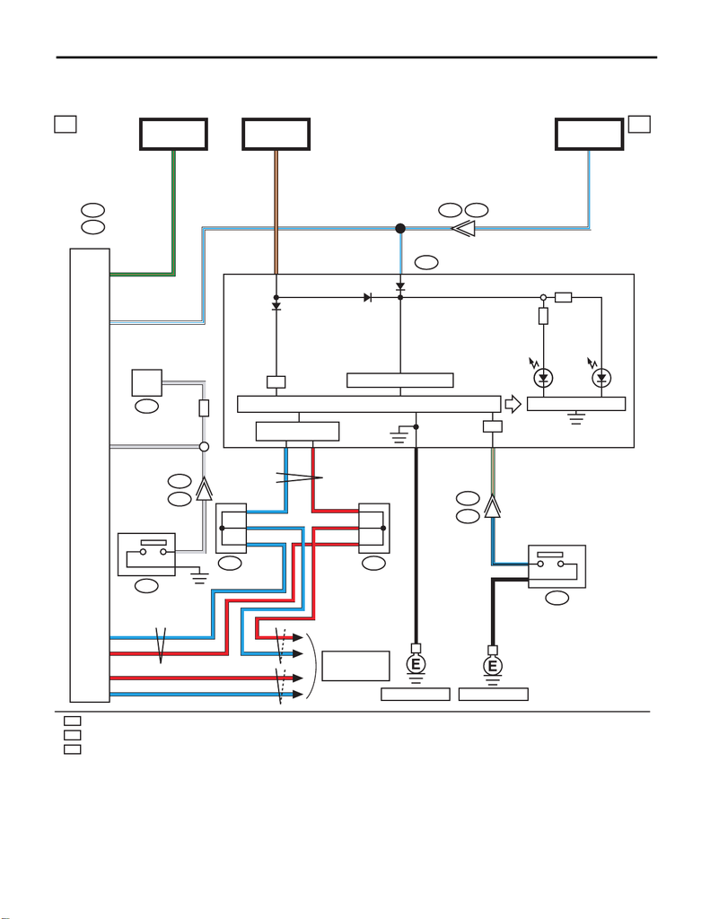

Parking Brake / Brake Fluid Level Warning Light System

WIRING SYSTEM

35.Parking Brake / Brake Fluid Level Warning Light System

A: WIRING DIAGRAM

WI-44512

3

WN

FA

R4

B16

B552

i230

i10

I/F

I/F

B281

B

i84

C

13

R167

i102

14

W/L W/L

FA

WN

EJ

B

GR GR

40

23

20

38

R33

L32

G/R

W/L

B

B

W/L

L/B

B2

1

B20

B28

R

L

GR

C32

1

C35

C27

L

1

1

L

1

1

1

1

L

R

R

R

R

L

R

L

EJ

:

:

J/C

i233

J/C

i232

1

: ENGINE TYPE EJ

: ENGINE TYPE FA

: WITH NAVIGATION

POWER SUPPLY CIRCUIT

NAVIGATION

UNIT

FB-18

F/B FUSE NO. 7

(B)

BODY INTEGRATED UNIT

DRIVE CIRCUIT

PARKING BRAKE/

BRAKE FLUID LEVEL/

BRAKE VACUUM PUMP

PARKING BRAKE/

BRAKE FLUID LEVEL

MICRO COMPUTER

CAN TRANSCEIVER &

RECEIVER

COMBINATION METER

BRAKE FLUID

LEVEL SWITCH

FB-38

F/B FUSE NO. 12

(IG)

FB-12

F/B FUSE NO. 2

(IG)

PARKING

BRAKE SWITCH

REF. TO CAN

COMMUNICATION

SYSTEM [b]

: TERMINAL No. OPTIONAL ARRANGEMENT

[figure not shown]

Parking Brake / Brake Fluid Level Warning Light System

WIRING SYSTEM

i233

i232

78

5

6

34

21

WI-44513

b b

i10

11 12

9

10

2

18

20

21 22 23 24 26

25

17

(GR)

B16

1

2

29

2524

16

30

98

17 18 19

20

28

21 22 23

3231

26 27

33 34 35

19

18

21

20

17

1

23

4

56

27

28 29 30

31 32 33 34 35

798

89

19 20

i102

i146D:

15

16

13

1411

12

9

10

R4

(B)

1

i229

6789

10 11 12

i230

(GR)

10

13

14 15 16 17

1211

12 78

9

LIST OF CONNECTORS